# Time Series Regression for Predicting Macroeconomic Indicators

Yusuf Ulucoban - Spring 2021 - IE360

26 04 2021

# Introduction

In this case, the aim will be to develop a time series regression model to predict macroeconomic indicator such as “Purchase of Vehicles”. In order to create a valid and sufficient model, we will be using different kinds of data that will be mentioned. First of all, to make things clear, all data below are taken from the Data Delivery System of Central Bank of the Republic of Turkey Electronic: [EVDS](https://evds2.tcmb.gov.tr/).  
To make a certain prediction for Consumer Price Index for Purchase of Vehicles in April 2021, different kinds of data are used, such as previous “Purchase of Vehicles”, Dollar exchange rates because purchases are usually generated with Dollar, interest rates since it is a powerful sign of an economic and survey questions that measures the effects of economic situation on people. There are two different survey questions. One of them measures the probability of buying a car over the next 12 months and the other one measures general economic situation expectation over the next 12 months. Firstly every data will be analyzed, their correlation will be checked and if there is an important relation, the data will be used for the prediction model. It should be noted that the steps will be developed by trials.

The first 10 rows and the structure of data are shown below is manipulated for further steps.

```
##          Date Survey.vehicle Survey.situation   Dollar Purchase Interest
## 1  2012-01-01       14.05483        102.24720 1.838936   132.71  15.0400
## 2  2012-02-01       11.94192        103.48562 1.751090   132.40  14.8200
## 3  2012-03-01       11.69320        102.92138 1.779295   131.80  13.3940
## 4  2012-04-01       12.72771         94.76370 1.779840   132.34  13.1650
## 5  2012-05-01       12.47089        102.16517 1.796955   132.32  12.9875
## 6  2012-06-01       11.82328         97.99052 1.816071   132.39  12.9860
## 7  2012-07-01       10.70188         99.41200 1.804886   132.32  13.3800
## 8  2012-08-01       11.07450         95.54813 1.785840   132.23  13.3780
## 9  2012-09-01       12.69445         90.50842 1.795630   131.31  12.9950
## 10 2012-10-01       10.95373         85.73654 1.794140   131.36  12.7700
```

```
## 'data.frame':    111 obs. of  6 variables:
##  $ Date            : Date, format: "2012-01-01" "2012-02-01" ...
##  $ Survey.vehicle  : num  14.1 11.9 11.7 12.7 12.5 ...
##  $ Survey.situation: num  102.2 103.5 102.9 94.8 102.2 ...
##  $ Dollar          : num  1.84 1.75 1.78 1.78 1.8 ...
##  $ Purchase        : num  133 132 132 132 132 ...
##  $ Interest        : num  15 14.8 13.4 13.2 13 ...
```

# Analysis of Purchase of Vehicles: The Target Variable

For better understanding of the target variable, CPI for Purchase of Vehicles, plotting could be an option to reach a better point.

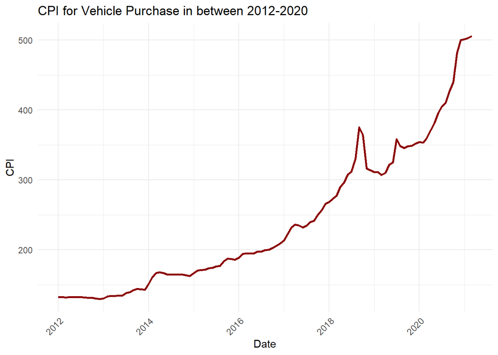

As you can guess, fitting a trend line is not easy because the line increases exponentially. For an increase that is exponential, using logarithm function to find a better trend is usually advantageous. Let’s look what logarithm of the CPI looks like.

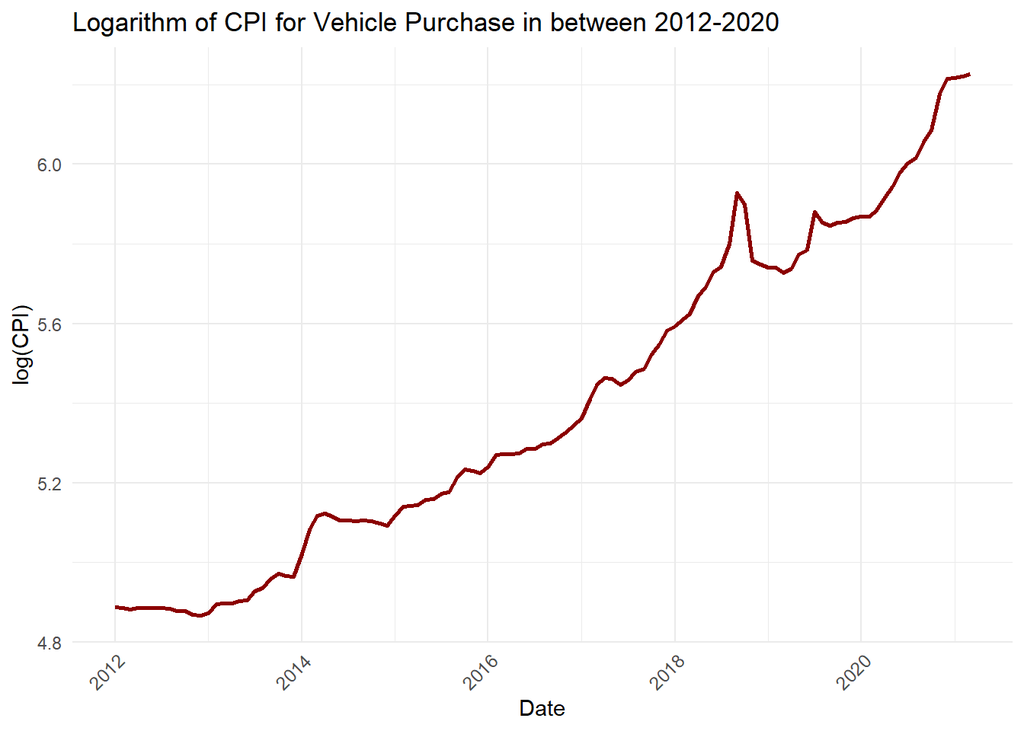

Now, as you can observe, the line seems less exponential which makes easy to fit a trend line. Let’s add their basic trend lines to see which one is likely to be improved.

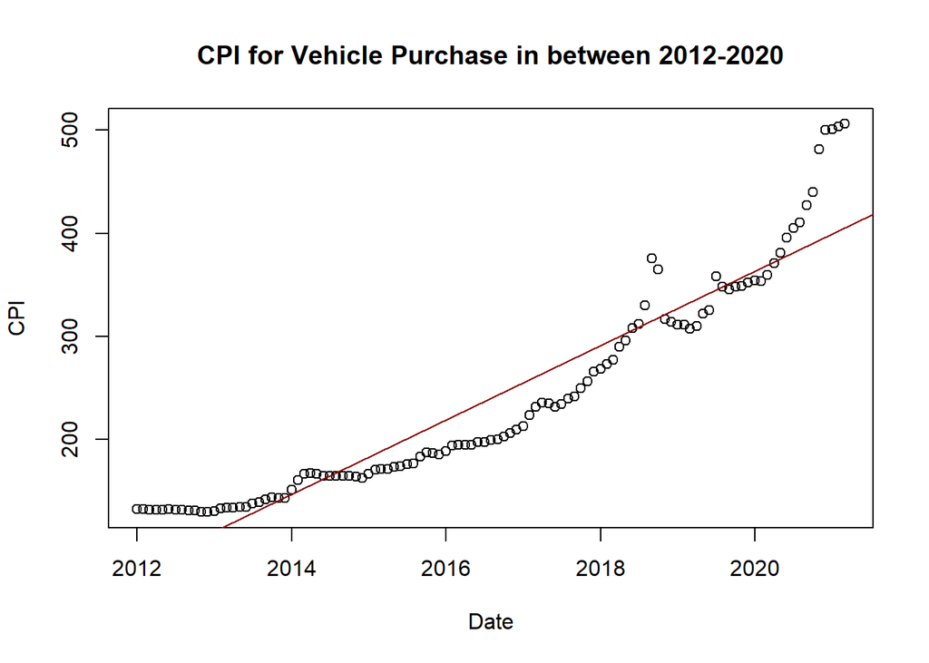

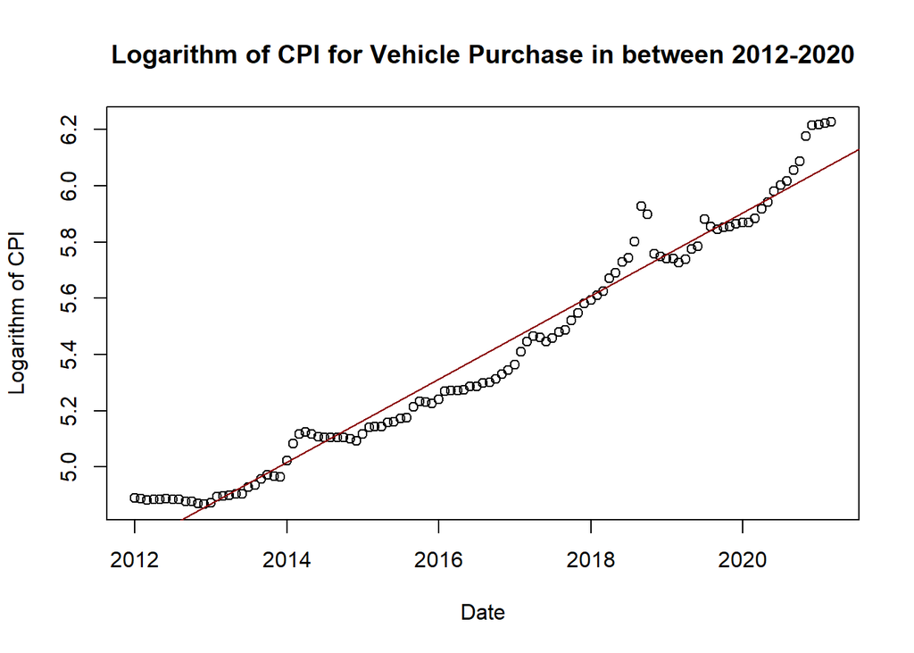

The trend line seems more accurate to be improved in the logarithm version than the normal version. Because seasonal and other kind of trends can interfere and affect our forecasting model, it is hard to say that the logarithm version is surely better. However, it is likely to be improved. The further analysis such as correlations will conclude that which one will be used in the forecasting model.  
Additionally, it is better to check that are there any monthly similarities such as all Augusts are maximums of the each year or every winter purchases are decreasing etc. To reach an answer to that question, the autocorrelation function (ACR) that shows the relation of one month with previous months will be used. Also, examining autocorrelation functions for both Purchases and Logarithm of Purchases.

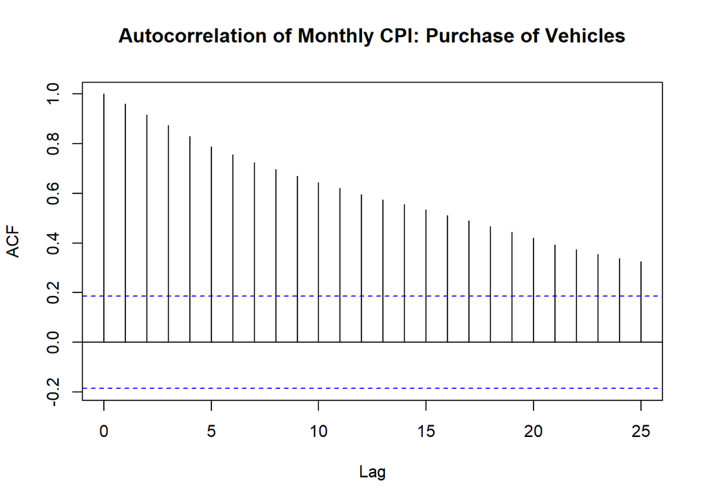

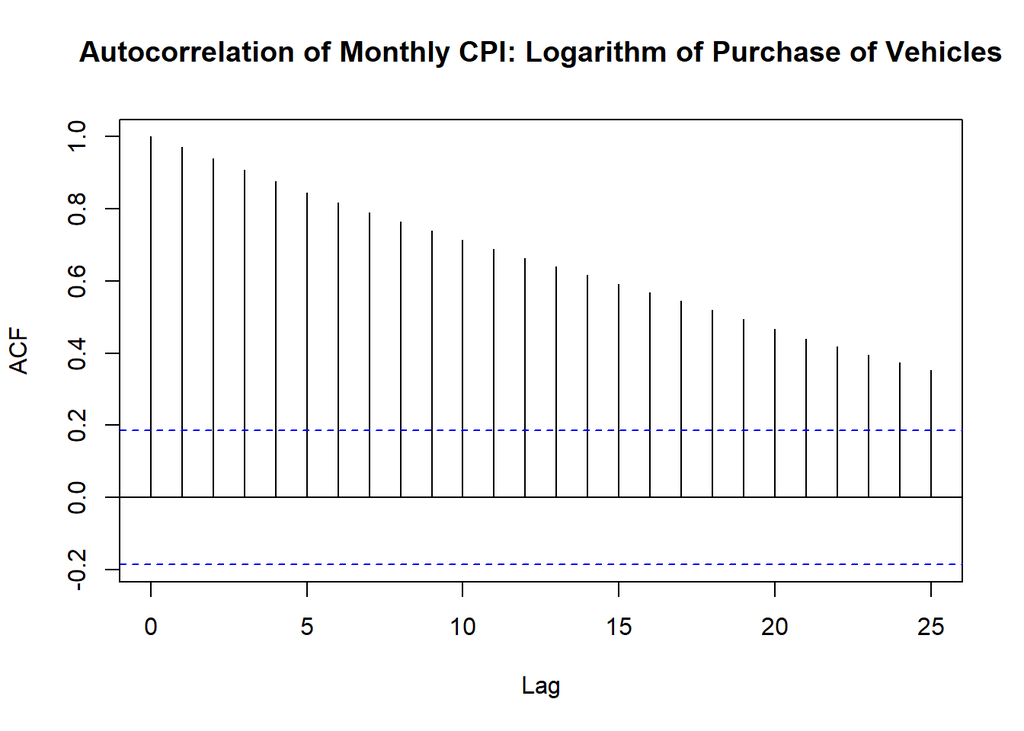

As a result of trend line plots and autocorrelation plots, creating a forecast model on logarithm version seems better if there are not any problems with the correlations that will be examined in the next part.

# Analyses of Other Possible Independent Variables

Firstly, it should be clarified the reasons of the importance for each data. For USD Exchange Rates, the vehicles are usually produced abroad which leads us to think that, if the exchange rates increase, a country will be less powerful to buy new vehicles. For Interest Rates, it shows the power of the economic in the country, which is another important indicator for macroeconomic measures. Variables include two different survey results. Vehicle survey has the answers of the question that “What is your probability to purchase a new car in next 12 months?”. Additionally, Situation survey has the answers of the question that “What is your general economic situation expectation in next 12 months?”.  
Before moving to further analyses to calculate correlations between variables, let’s plot all columns to see are there any important similarities between them. Because their measures are hard to compare, we divided CPI by 10 and multiplied Logarith of CPI with 5 to show in one exact chart.

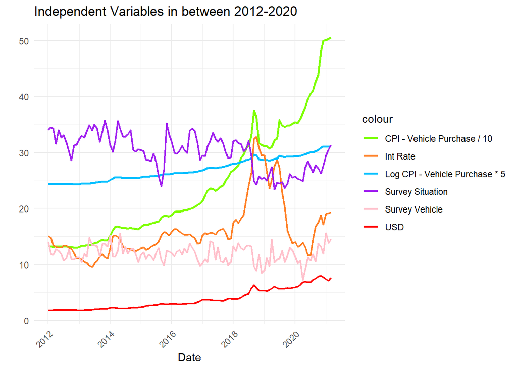

It can be seen that, they have similarities between different pairs. One of them is the peek in late 2018 that is obvious for green and orange lines. Another one is the oscillation that is accurate for both survey results. Another important similarity is between red line that shows USD exchange rate and blue line that shows the logarithm of CPI.  
For better and exact calculations, let’s have a look their correlations with each other.

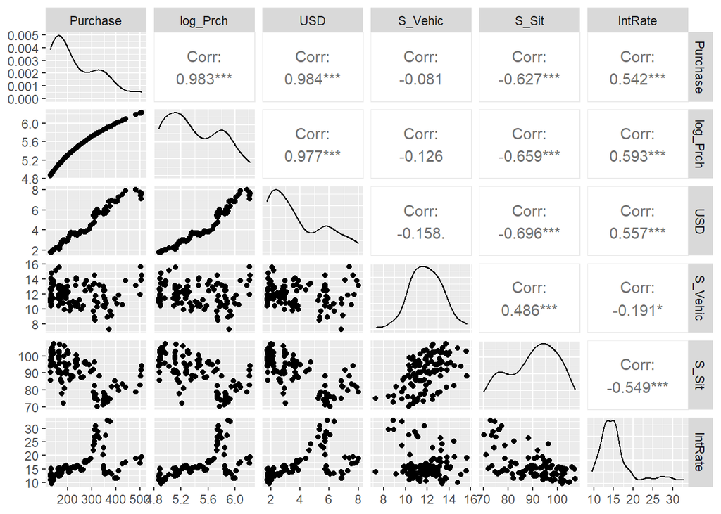

In this part, the correlation between independent variables and purchases is compared to the correlation between independent variables and logarithm of purchases. Although there differences are very small and negligble, with the result that is driven from analysis of CPI: Purchase of Vehicles, continuing with the logarithm version to create a better forecast would be wise.

# Forecasting Models

### Model 1

After deciding to create a model over the logarithm of the previous CPI’s: Purchase of Vehicles, the USD with 0.98, situation survey with -0.66 and interest rate with 0.6 correlations will be used in the first forecasting model.

```r
model1=lm( log_Prch ~ USD + IntRate + S_Sit, corrdata)
summary(model1)
```

```
##
## Call:
## lm(formula = log_Prch ~ USD + IntRate + S_Sit, data = corrdata)
##
## Residuals:
##      Min       1Q   Median       3Q      Max
## -0.17720 -0.07818  0.02372  0.05203  0.17831
##
## Coefficients:
##             Estimate Std. Error t value Pr(>|t|)
## (Intercept) 4.237175   0.128504  32.973  < 2e-16 ***
## USD         0.212887   0.006162  34.549  < 2e-16 ***
## IntRate     0.006905   0.001919   3.598 0.000488 ***
## S_Sit       0.002812   0.001158   2.429 0.016797 *
## ---
## Signif. codes:  0 '***' 0.001 '**' 0.01 '*' 0.05 '.' 0.1 ' ' 1
##
## Residual standard error: 0.08206 on 107 degrees of freedom
## Multiple R-squared:  0.9597, Adjusted R-squared:  0.9586
## F-statistic: 850.3 on 3 and 107 DF,  p-value: < 2.2e-16
```

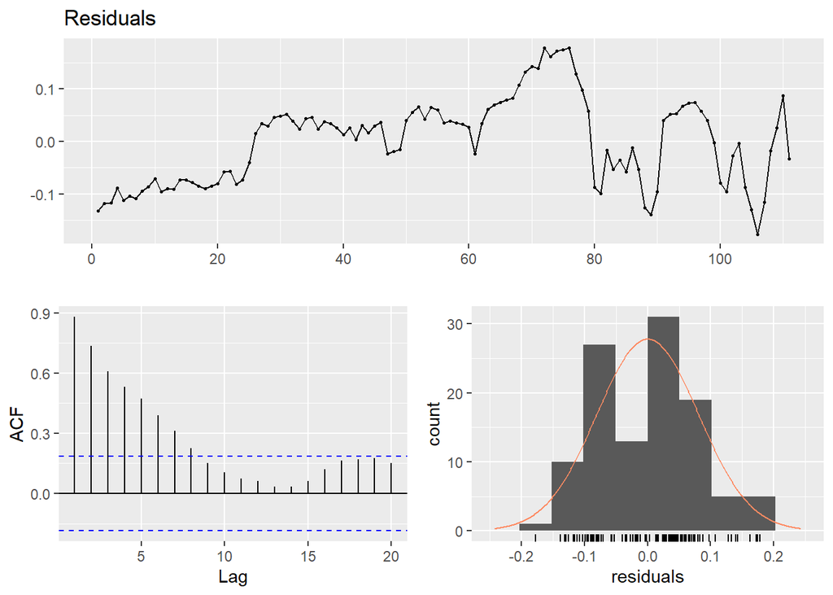

```
##
##  Breusch-Godfrey test for serial correlation of order up to 10
##
## data:  Residuals
## LM test = 89.361, df = 10, p-value = 7.168e-15
```

```r
checkresiduals(model1)
```

Although the model has a nice Adjusted R Squared value and p-value, the plot of the residuals seems a bit problematic. Residuals vary from -0.2 to 0.2 which are higher values than they should be and its oscillations should occur less. Also, ACF graph shows that residuals are not clearly independent from each other. The lines over the blue lines represents an issue about affecting the residuals that happens after the one. Lastly, it is also needed that the last graph should look alike to the normal distribution function. Let’s examine that could adding a trend variable makes things better.

### Model 2

```r
corrdata=data.table(corrdata)
corrdata[, trend:= c(1:.N)]
model2=lm( log_Prch ~ USD + IntRate + S_Sit + trend, corrdata)
summary(model2)
```

```
##
## Call:
## lm(formula = log_Prch ~ USD + IntRate + S_Sit + trend, data = corrdata)
##
## Residuals:
##       Min        1Q    Median        3Q       Max
## -0.109537 -0.029139 -0.000051  0.025725  0.090541
##
## Coefficients:
##              Estimate Std. Error t value Pr(>|t|)
## (Intercept) 4.2853306  0.0641220  66.831  < 2e-16 ***
## USD         0.1013361  0.0069128  14.659  < 2e-16 ***
## IntRate     0.0052887  0.0009610   5.503 2.61e-07 ***
## S_Sit       0.0028938  0.0005771   5.014 2.15e-06 ***
## trend       0.0069234  0.0003843  18.014  < 2e-16 ***
## ---
## Signif. codes:  0 '***' 0.001 '**' 0.01 '*' 0.05 '.' 0.1 ' ' 1
##
## Residual standard error: 0.04091 on 106 degrees of freedom
## Multiple R-squared:  0.9901, Adjusted R-squared:  0.9897
## F-statistic:  2647 on 4 and 106 DF,  p-value: < 2.2e-16
```

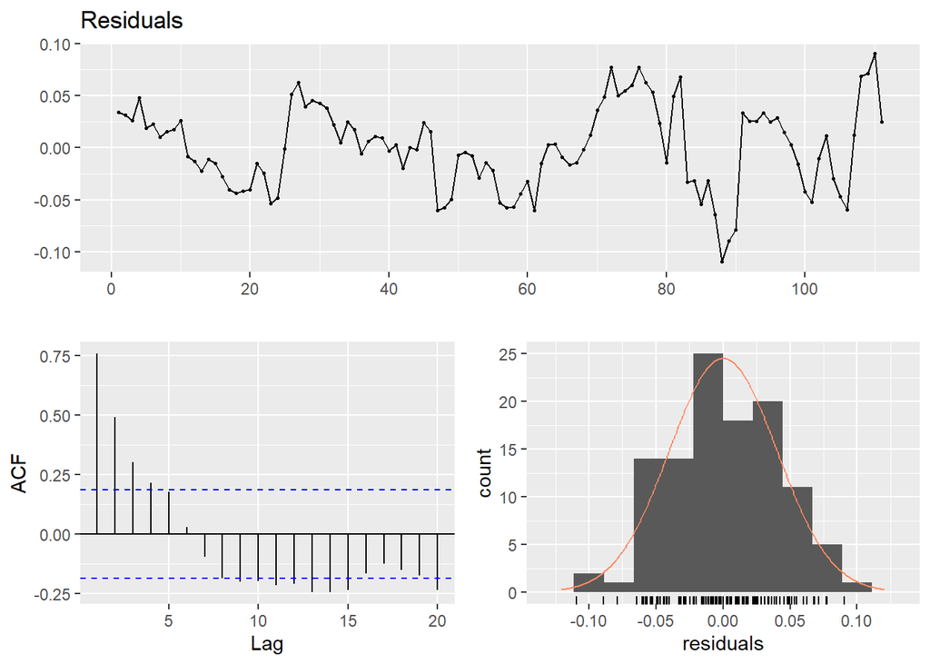

```
##
##  Breusch-Godfrey test for serial correlation of order up to 10
##
## data:  Residuals
## LM test = 73.651, df = 10, p-value = 8.704e-12
```

```r
checkresiduals(model2)
```

As a result, Model 2 seems better than the Model 1. However, the ACF function is still improvable. In order to reduce the effect of previous residuals to the new ones, let’s add a lag variable to forecasting model. For example: for t=2, lag variable will hold the value of the residual at t=1. Adding the lag variable to the forecasting model will decrease the number of lines that exceed blue line in the ACR plot, which means there will be less correlation between old residuals with the new one.

### Model 3

```r
corrdata[ , lag1:=shift(residuals(model2),1)]
model3=lm( log_Prch ~ USD + IntRate + S_Sit + trend +lag1, corrdata)
summary(model3)
```

```
##
## Call:
## lm(formula = log_Prch ~ USD + IntRate + S_Sit + trend + lag1,
##     data = corrdata)
##
## Residuals:
##       Min        1Q    Median        3Q       Max
## -0.088146 -0.012450 -0.001846  0.010406  0.089548
##
## Coefficients:
##              Estimate Std. Error t value Pr(>|t|)
## (Intercept) 4.3695813  0.0414194 105.496  < 2e-16 ***
## USD         0.1000042  0.0044771  22.337  < 2e-16 ***
## IntRate     0.0049298  0.0006141   8.027 1.60e-12 ***
## S_Sit       0.0020963  0.0003733   5.615 1.65e-07 ***
## trend       0.0068940  0.0002513  27.435  < 2e-16 ***
## lag1        0.7842846  0.0627810  12.492  < 2e-16 ***
## ---
## Signif. codes:  0 '***' 0.001 '**' 0.01 '*' 0.05 '.' 0.1 ' ' 1
##
## Residual standard error: 0.02603 on 104 degrees of freedom
##   (1 observation deleted due to missingness)
## Multiple R-squared:  0.996,  Adjusted R-squared:  0.9958
## F-statistic:  5186 on 5 and 104 DF,  p-value: < 2.2e-16
```

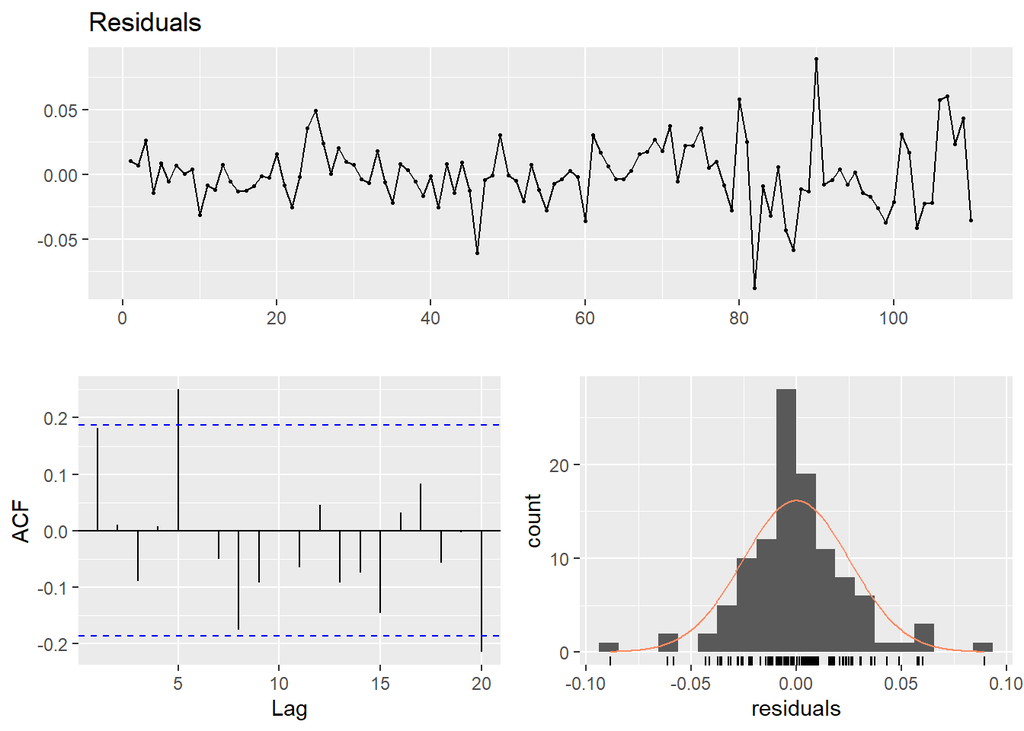

```
##
##  Breusch-Godfrey test for serial correlation of order up to 10
##
## data:  Residuals
## LM test = 28.534, df = 10, p-value = 0.001482
```

```r
checkresiduals(model3)
```

As it is guessed, the Model 3 turns out to be more clear and better. Residuals plot has less maximum and minimum values with less oscillations. ACF plot has way better compared the previous ones although there are two lines that exceeds blue line. Also, residuals are distributed much more normally.Since the Model 3 seems the best one so far, further anaylyses will be made with it.  
Before moving to fitted vs actual values, it is better check that residuals are distributed around 0. Plotting fitted vs residuals may be advantageous.

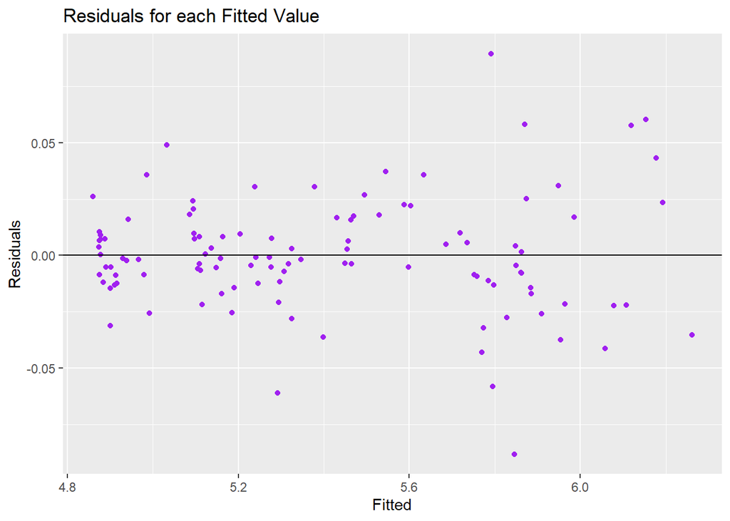

Although there are some dots with 0.1 errors, they may be named as outlier and be ignored.  
Since the residuals are good enough to compare actual and fitted values, let’s plot the predicted and actual values.

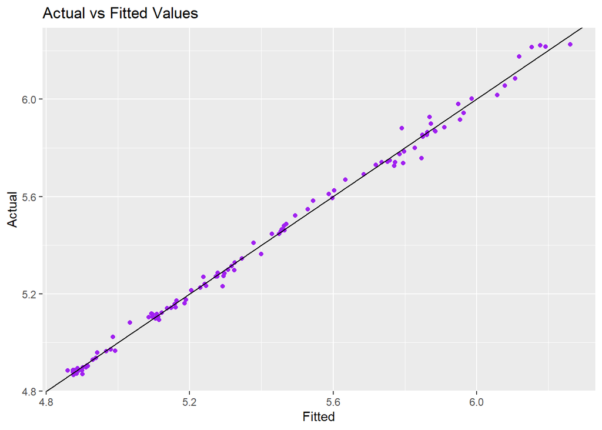

A line of Fitted=Actual is also added to make comparisons easy. As you can observe, the graph seems accurate enough to move to the next part that is plotting the prediction model for whole time series and compare it with the actual CPI: Purchase of Vehicles.

# Plotting the Forecast Model

After applying the forecast formula for previous months, the forecast data for previous months is added. Then, the forecast and actual values are plotted to visualize.

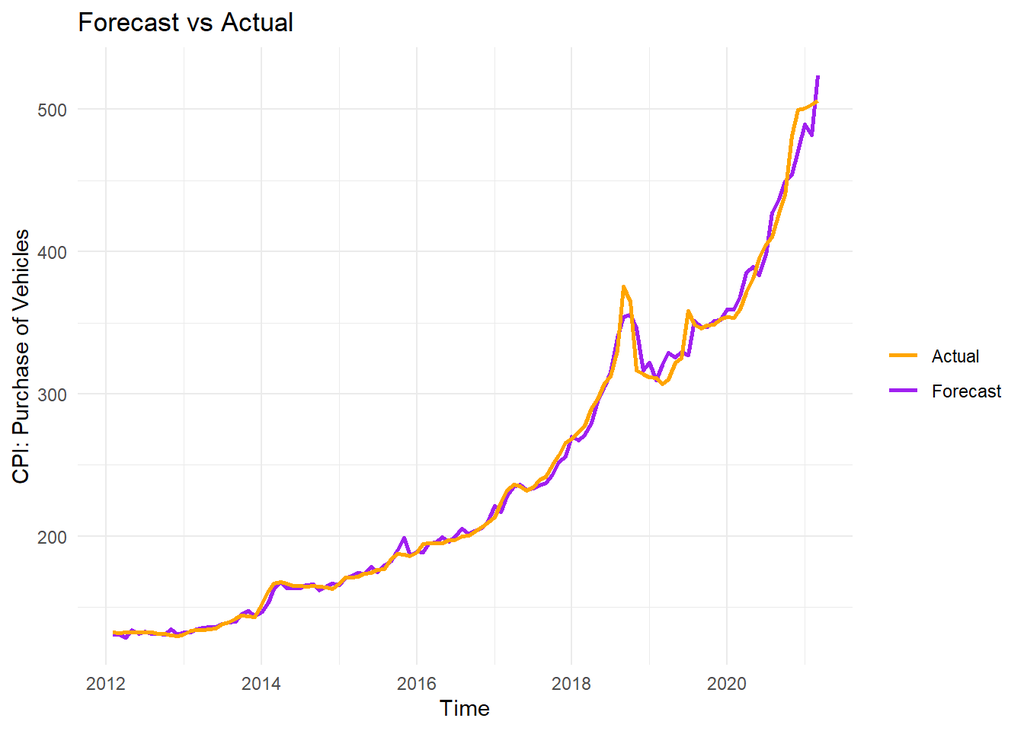

# Forecast of the Next Month: April 2021

Lastly, as a result of the study the April 2021 forecast for the CPI: Purchase of Vehicles is derived from the Model 3.

```r
pred4.21
```

```
##        1
## 520.3584
```

# Conclusion

**To reach the RMD file and the codes of this study, please [Click](https://bu-ie-360.github.io/spring21-yulucoban/files/Homework2.Rmd).**